# text_summartization

*Name*: `Venkata Skandha Rajendra Varma`

*Student No*: `GH1036345`

*Sunject*: `Big Data Analytics - M508B`

**Business Objective**

As a leading news provider like CNN, our goal is to adapt to changing user behavior by offering quick, digestible news content through a mobile app. With users having less time to read full articles, we aim to increase engagement and retention by delivering short, high-quality news snippets. To support this, we are building an NLP-based summarization system that converts long news articles into concise summaries without losing core information or tone.

**Problem Statement**

Today’s users often lack the time to read lengthy news articles, leading to reduced engagement and incomplete understanding of current events. Traditional news formats are not optimized for mobile, on-the-go consumption. To solve this, we propose an NLP-driven solution that summarizes full-length news into short, coherent snippets for mobile display. The challenge is to ensure that these summaries are accurate, grammatically sound, and informative while maintaining the integrity of the original content.

```python
import os
os.getcwd()
```

```
'C:\\Users\\skand\\Documents\\Gisma Subjects\\2nd Semeseter 1 Quater\\NLP\\Final NLP Project\\archive\\cnn_dailymail'
```

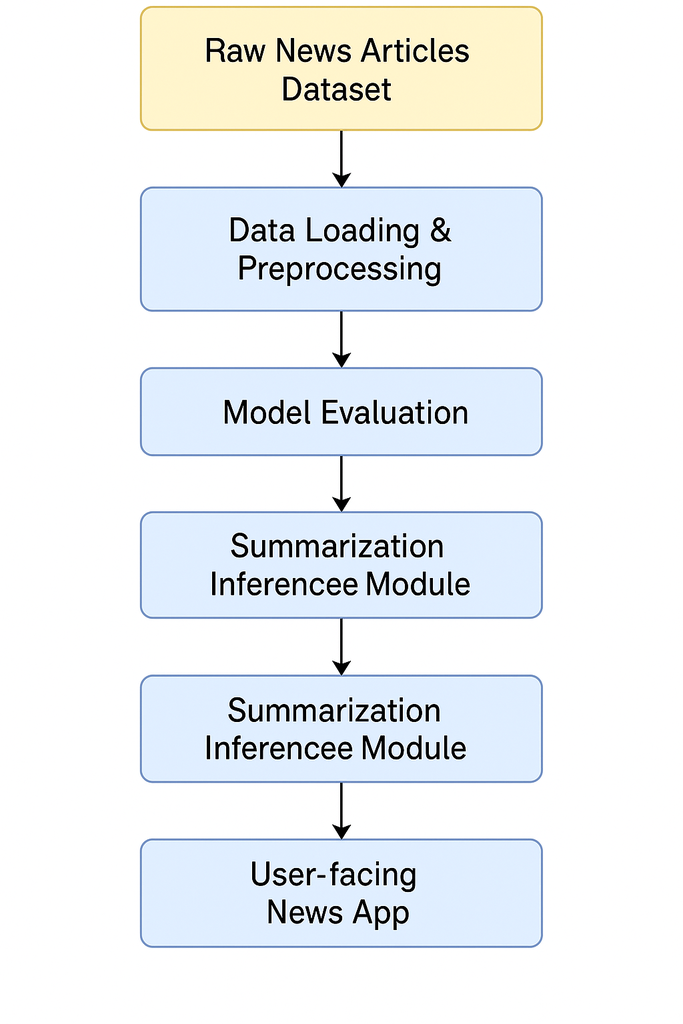

```python
from IPython.display import Image
# Image(filename='C:\Users\skand\Documents\Gisma Subjects\2nd Semeseter 1 Quater\NLP\Final NLP Project\archive\cnn_dailymail/SYStem Design.png')
Image(filename=r'C:\Users\skand\Documents\Gisma Subjects\2nd Semeseter 1 Quater\NLP\Final NLP Project\archive\cnn_dailymail\SYStem Design.png')
```

**IMPORTING DEPENDENCIES**

```python
import pandas as pd
from datasets import Dataset
from transformers import BartTokenizer
```

**LOADING DATA**

Kaggle Dataset: https://www.kaggle.com/datasets/gowrishankarp/newspaper-text-summarization-cnn-dailymail

Here the data is already split into TEST, TRAIN and VALIDATION sets.

```python
# Load CSV files
train_df = pd.read_csv("train.csv")
val_df = pd.read_csv("validation.csv")
test_df = pd.read_csv("test.csv")
```

```python
print(train_df.columns)
print(val_df.columns)
print(test_df.columns)
```

```
Index(['id', 'article', 'highlights'], dtype='object')
Index(['id', 'article', 'highlights'], dtype='object')
Index(['id', 'article', 'highlights'], dtype='object')
```

**Here we are scaling dow the dataset to make it more manageable for testing purposes.**

```python
train_df_small = train_df.sample(n=1000, random_state=42).reset_index(drop=True)
val_df_small = val_df.sample(n=125, random_state=42).reset_index(drop=True)
test_df_small = test_df.sample(n=125, random_state=42).reset_index(drop=True)
```

We are renaming the columns to make them more intuitive for our summarization task. The 'article' column will contain the full text of the news article, and the 'highlights' column will contain the summary of that article.

```python
train_df_small = train_df_small.rename(columns={'article': 'input_text', 'highlights': 'summary'})
val_df_small = val_df_small.rename(columns={'article': 'input_text', 'highlights': 'summary'})
test_df_small = test_df_small.rename(columns={'article': 'input_text', 'highlights': 'summary'})
```

In these lines, we are converting the smaller versions of our pandas DataFrames (`train_df_small`, `val_df_small`, and `test_df_small`) into Hugging Face `Dataset` objects. This format is optimized for use with the Hugging Face Transformers library and enables efficient preprocessing, tokenization, and integration with model training pipelines.

```python
# Convert to Hugging Face Dataset
train_dataset = Dataset.from_pandas(train_df_small)
val_dataset = Dataset.from_pandas(val_df_small)
test_dataset = Dataset.from_pandas(test_df_small)
```

We are loading the pretrained BART tokenizer from the 'facebook/bart-base' model. The tokenizer is responsible for converting raw text into token IDs that the BART model can understand, ensuring the input format matches what the model was trained on.

*Why We Use BART for Summarization* We use BART (facebook/bart-base) because it is specifically designed for abstractive summarization, meaning it can generate short, rephrased versions of longer texts — ideal for news snippets.

Key Advantages:

```python
# Load tokenizer
tokenizer = BartTokenizer.from_pretrained('facebook/bart-base')
```

This function tokenizes the input articles and their summaries for the BART model. It truncates and pads the inputs to fixed lengths (1024 for articles, 128 for summaries) and prepares the summaries as labels for training. This formats the data correctly for the model to learn from.

```python
# Tokenization function
def preprocess_data(examples):
    model_inputs = tokenizer(examples["input_text"], max_length=1024, truncation=True, padding="max_length")
    with tokenizer.as_target_tokenizer():
        labels = tokenizer(examples["summary"], max_length=128, truncation=True, padding="max_length")
    model_inputs["labels"] = labels["input_ids"]
    return model_inputs
```

```python
print(train_dataset.column_names)
```

```
['id', 'input_text', 'summary']
```

These lines apply the `preprocess_data` function to the entire training, validation, and test datasets using the Hugging Face `map` method. This tokenizes all examples in batches, preparing the datasets in the correct format for model training and evaluation.

```python
# Tokenize datasets
tokenized_train = train_dataset.map(preprocess_data, batched=True)
tokenized_val = val_dataset.map(preprocess_data, batched=True)
tokenized_test = test_dataset.map(preprocess_data, batched=True)

# Model & Trainer code remains unchanged
```

```
  warnings.warn(
```

This code below loads the pretrained BART model and sets up `training parameters like batch size, epochs,` and `logging`. It then initializes a Hugging Face `Trainer` with the model, tokenized datasets, and tokenizer, and starts fine-tuning the model on the training data.

```python
import transformers
from transformers import BartForConditionalGeneration, TrainingArguments, Trainer

model = BartForConditionalGeneration.from_pretrained('facebook/bart-base')

training_args = TrainingArguments(
    output_dir="./results",
    per_device_train_batch_size=2,
    per_device_eval_batch_size=2,
    num_train_epochs=2,
    save_strategy="epoch",
    logging_dir="./logs",
    logging_steps=10,
    save_total_limit=2,
    fp16=True,
)


trainer = Trainer(
    model=model,
    args=training_args,
    train_dataset=tokenized_train,
    eval_dataset=tokenized_val,
    tokenizer=tokenizer,
)

trainer.train()
```

```
WARNING:tensorflow:From c:\Users\skand\AppData\Local\Programs\Python\Python310\lib\site-packages\tf_keras\src\losses.py:2976: The name tf.losses.sparse_softmax_cross_entropy is deprecated. Please use tf.compat.v1.losses.sparse_softmax_cross_entropy instead.
```

[1000/1000 1:21:24, Epoch 2/2]

| Step | Training Loss |
| --- | --- |
| 10 | 7.301800 |
| 20 | 5.810800 |
| 30 | 4.296600 |
| 40 | 3.646200 |
| 50 | 2.866000 |
| 60 | 2.473300 |
| 70 | 2.153900 |
| 80 | 1.858600 |
| 90 | 1.569900 |
| 100 | 1.373800 |
| 110 | 1.638000 |
| 120 | 1.230000 |
| 130 | 1.612000 |
| 140 | 1.532300 |
| 150 | 1.415000 |
| 160 | 1.368500 |
| 170 | 1.260000 |
| 180 | 1.553700 |
| 190 | 1.470400 |
| 200 | 1.218100 |
| 210 | 1.390500 |
| 220 | 1.247500 |
| 230 | 1.508500 |
| 240 | 1.510900 |
| 250 | 1.180900 |
| 260 | 1.220400 |
| 270 | 1.299100 |
| 280 | 1.334800 |
| 290 | 1.376600 |
| 300 | 1.174100 |

[output cut: 70 more lines]

```
TrainOutput(global_step=1000, training_loss=1.3467417368888854, metrics={'train_runtime': 4892.6974, 'train_samples_per_second': 0.409, 'train_steps_per_second': 0.204, 'total_flos': 1219472916480000.0, 'train_loss': 1.3467417368888854, 'epoch': 2.0})
```

```python
import evaluate

# Load the ROUGE metric using the new evaluate library
rouge = evaluate.load("rouge")

def compute_metrics(eval_preds):
    preds, labels = eval_preds
    decoded_preds = tokenizer.batch_decode(preds, skip_special_tokens=True)
    decoded_labels = tokenizer.batch_decode(labels, skip_special_tokens=True)

    # Compute ROUGE scores
    result = rouge.compute(predictions=decoded_preds, references=decoded_labels, use_stemmer=True)

    # Convert result to a simpler format
    return {key: value.mid.fmeasure * 100 for key, value in result.items()}

# Evaluate on the test set using a Hugging Face Trainer
trainer.evaluate(eval_dataset=tokenized_test, metric_key_prefix="test")
```

[63/63 00:38]

```
{'test_loss': 1.1153616905212402,
 'test_runtime': 39.487,
 'test_samples_per_second': 3.166,
 'test_steps_per_second': 1.595,
 'epoch': 2.0}
```

At last we have loaded fine-tuned BART model and tokenizer from your local checkpoint, sets the model to evaluation mode, then generates and prints summaries for the first 5 test articles. For each article, it tokenizes the input, generates a summary with beam search, decodes the summary back to text, and compares it to the actual reference summary. This helps you see how well the model summarizes real examples.

```python
from transformers import BartForConditionalGeneration, BartTokenizer

# Load model and tokenizer (if not already loaded)
model = BartForConditionalGeneration.from_pretrained('C:\\Users\\skand\\Documents\\Gisma Subjects\\2nd Semeseter 1 Quater\\NLP\\Final NLP Project\\archive\\cnn_dailymail\\results\\checkpoint-1000')  # or 'facebook/bart-base' if base model
tokenizer = BartTokenizer.from_pretrained('C:\\Users\\skand\\Documents\\Gisma Subjects\\2nd Semeseter 1 Quater\\NLP\\Final NLP Project\\archive\\cnn_dailymail\\results\\checkpoint-1000')

# Put model in eval mode
model.eval()

for i in range(5):
    input_text = test_df.iloc[i]['article']  # original article
    actual_summary = test_df.iloc[i]['highlights']  # actual summary

    # Tokenize input
    inputs = tokenizer([input_text], max_length=1024, truncation=True, return_tensors='pt')

    # Generate summary (adjust parameters if needed)
    summary_ids = model.generate(
        inputs['input_ids'],
        num_beams=4,
        max_length=128,
        early_stopping=True
    )

    # Decode generated summary
    predicted_summary = tokenizer.decode(summary_ids[0], skip_special_tokens=True)

    print(f"---- Example {i+1} ----")
    print(f"Original Article:\n{input_text[:300]}...")  # print first 300 chars for brevity
    print(f"Actual Summary:\n{actual_summary}")
    print(f"Predicted Summary:\n{predicted_summary}")
    print("\n")
```

```
---- Example 1 ----
Original Article:
Ever noticed how plane seats appear to be getting smaller and smaller? With increasing numbers of people taking to the skies, some experts are questioning if having such packed out planes is putting passengers at risk. They say that the shrinking space on aeroplanes is not only uncomfortable - it's …
Actual Summary:
Experts question if  packed out planes are putting passengers at risk .
U.S consumer advisory group says minimum space must be stipulated .
Safety tests conducted on planes with more leg room than airlines offer .
Predicted Summary:
U.S. consumer advisory group set up to set standards for animals flying on planes is questioning if having such packed out planes is putting passengers at risk .
They say that the shrinking space on aeroplanes is not only uncomfortable - it's putting our health and safety in danger .


---- Example 2 ----
Original Article:
A drunk teenage boy had to be rescued by security after jumping into a lions' enclosure at a zoo in western India. Rahul Kumar, 17, clambered over the enclosure fence at the Kamla Nehru Zoological Park in Ahmedabad, and began running towards the animals, shouting he would 'kill them'. Mr Kumar expla…
Actual Summary:
Drunk teenage boy climbed into lion enclosure at zoo in west India .
Rahul Kumar, 17, ran towards animals shouting 'Today I kill a lion!'
Fortunately he fell into a moat before reaching lions and was rescued .
Predicted Summary:
Rahul Kumar, 17, clambered over the enclosure fence at the Kamla Nehru Zoological Park in Ahmedabad .
He shouted 'Today I kill a lion or a lion kills me!'


---- Example 3 ----
Original Article:
Dougie Freedman is on the verge of agreeing a new two-year deal to remain at Nottingham Forest. Freedman has stabilised Forest since he replaced cult hero Stuart Pearce and the club's owners are pleased with the job he has done at the City Ground. Dougie Freedman is set to sign a new deal at Notting…
Actual Summary:
Nottingham Forest are close to extending Dougie Freedman's contract .
The Forest boss took over from former manager Stuart Pearce in February .
Freedman has since lead the club to ninth in the Championship .
Predicted Summary:
Dougie Freedman is set to sign a new two-year deal at Nottingham Forest .
Freedman has stabilised Forest since he replaced cult hero Stuart Pearce .
The club's owners are pleased with the job he has done at the City Ground .


---- Example 4 ----
Original Article:
Liverpool target Neto is also wanted by PSG and clubs in Spain as Brendan Rodgers faces stiff competition to land the Fiorentina goalkeeper, according to the Brazilian's agent Stefano Castagna. The Reds were linked with a move for the 25-year-old, whose contract expires in June, earlier in the seaso…
Actual Summary:
Fiorentina goalkeeper Neto has been linked with Liverpool and Arsenal .
Neto joined Firoentina from Brazilian outfit Atletico Paranaense in 2011 .
He is also wanted by PSG and Spanish clubs, according to his agent .
CLICK HERE for the latest Liverpool news .
Predicted Summary:
Firoentina goalkeeper Neto is wanted by Liverpool and PSG .
Liverpool target Neto's agent Stefano Castagna claims he will have his pick of top European clubs when the transfer window re-opens in the summer .


---- Example 5 ----
Original Article:
Bruce Jenner will break his silence in a two-hour interview with Diane Sawyer later this month. The former Olympian and reality TV star, 65, will speak in a 'far-ranging' interview with Sawyer for a special edition of '20/20' on Friday April 24, ABC News announced on Monday. The interview comes amid…
Actual Summary:
Tell-all interview with the reality TV star, 69, will air on Friday April 24 .
It comes amid continuing speculation about his transition to a woman and following his involvement in a deadly car crash in February .
The interview will also be one of Diane Sawyer's first appearances on television following the sudden death of her husband last year .
Predicted Summary:
Bruce Jenner will break his silence in a two-hour interview with Diane Sawyer later this month .
The former Olympian and reality TV star, 65, will speak out in a 'far-ranging' interview with Sawyer for a special edition of '20/20' on Friday April 24, ABC News announced on Monday .
```

**CONCLUSION**

In this project, we developed an application designed to serve news content in the form of concise, informative snippets through automatic summarization. This approach enables users to quickly grasp the essence of news articles without having to read the entire text. The underlying model can be further enhanced through advanced hyperparameter tuning, which would improve the quality and accuracy of the generated summaries.

Looking ahead, the application can be integrated into a backend system that fetches live news articles in real-time, processes them through the summarization model, and delivers up-to-date summaries to users instantly. This dynamic deployment would provide a seamless and efficient news consumption experience.

Moreover, the user interface of the app can be designed to allow users to click on the summarized text, offering an option to read the full original article if they wish to explore more details. This feature balances brevity with depth, catering to diverse user preferences.

Overall, this project lays the foundation for a practical news summarization tool that combines natural language processing with real-world application, with ample room for improvements and future expansions.